# edX - Statistics and R

Maurizio La Rosa

28/02/2021

# The Normal Distribution

The one that follows is the formula for the Normal distribution:

$Pr(a≤x≤b)=\int_{a}^{b}\frac{1}{\sigma\sqrt{2\pi}}e^{-\frac{1}{2}(\frac{x-\mu}{\sigma})^{2}}dx$

What is relevant is the fact that, despite the appearance of complexity, only two numbers are required to define the proportion of numbers between $a$ and $b$: those are $\mu$ and $\sigma$. Whatever $a$ and $b$, knowing the average and the standard deviation is sufficient to determine the proportion of data within that interval: for example, for normally distributed data, 95% of the data will be within two standard deviations from the average. Or 99% of the data will be within 2.5 standard deviations from the average. Or, finally, that around 68% of the data will lie within one standard deviation from the average.

### Load the data

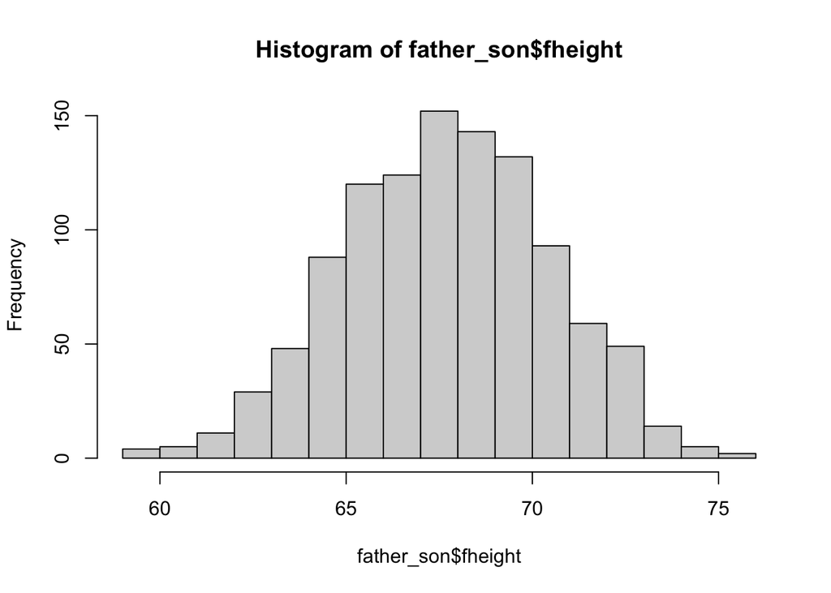

### Show the average and the standard deviation

The following is the formula for the average:

$\mu=\frac{1}{M}\sum_{i=1}^{M}x_i$

where $M$ is the total number of fathers whose height we collected, and $x_{i}$ is the height of the $i^{th}$ father.

```
## [1] 67.6871
```

The following is the formula for the variance. We compute its square root to get the standard deviation:

$\sigma^{2}=\frac{1}{M}\sum_{i=1}^{M}(x_{i}-\mu)^{2}$

```
## [1] 2.744868
```

From the above we see that the data for fathers’ heights are approximately normally distributed and that the average height is around 68 inches, while the standard deviation is around 3 inches. This means that if someone asked us to tell her the proportion of fathers whose height is within 65 and 71 inches, we could answer that it is 68%, since 65 and 71 inches are values within one standard deviation from the average.

### Plot the distribution of the fathers’ heights

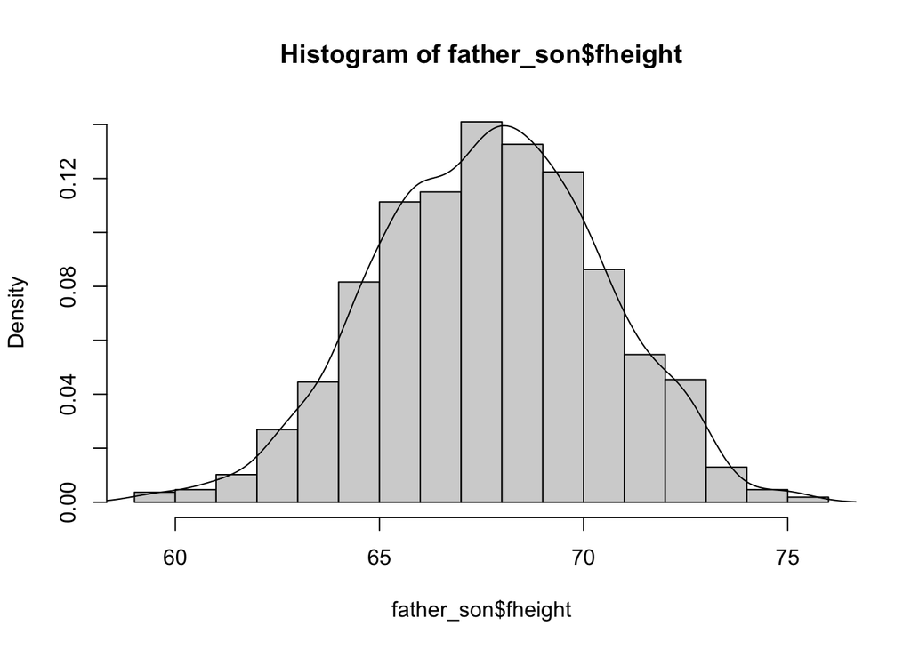

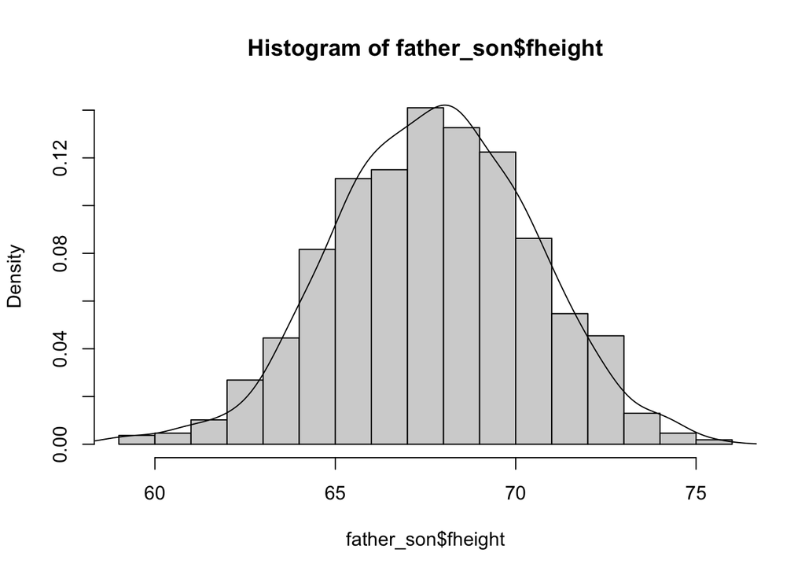

### Compare the percentiles for our data and the theoretical normal distribution (quantile quantile plot)

If we wanted to assess if the data were normally distributed, we could draw a quantile quantile plot. We draw the percentiles for the normally distributed data on the x axis, and the percentiles for our empirical data on the y axis. If the points fall on the identity line, a normal distribution is a good approximation for the distribution of our data.

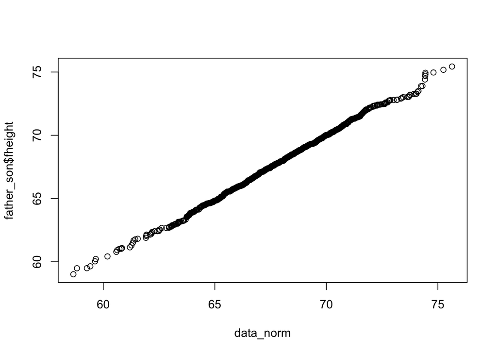

### Standard units

If we knew that our data were approximately normally distributed, we could convert them to standard units by subtracting the mean from them and dividing them for the standard deviation:

$Z_{i}=\frac{(X_{i}-\overline{X})}{s_{X}}$